# largescaledesigned – SMLP2024: Advanced Frequentist Track

Author

Phillip Alday, Douglas Bates, and Reinhold Kliegl

Published

2024-09-09

# 1 A large-scale designed experiment

Load the packages to be used.

```julia
using AlgebraOfGraphics
using CairoMakie
using Chain
using DataFrameMacros
using DataFrames
using Effects
using MixedModels
using MixedModelsMakie
using SMLP2024: dataset
using StandardizedPredictors
using StatsBase
```

The English Lexicon Project (Balota et al., 2007) was a large-scale multicenter study to examine properties of English words. It incorporated both a lexical decision task and a word recognition task. Different groups of subjects participated in the different tasks.

# 2 Extracting data tables from the raw data

The raw data are available as an [OSF project](https://osf.io/n63s2) as Zip files for each of the tasks. These Zip files contain one data file for each participant, which has a mixture of demographic data, responses on some pre-tests, and the actual trial runs.

Parsing these data files is not fun – see [this repository](https://github.com/dmbates/EnglishLexicon.jl) for some of the code used to untangle the data. (This repository is an unregistered Julia package.)

Some lessons from this:

- When an identifier is described as a “unique subject id”, it probably isn’t.
- In a multi-center trial, the coordinating center should assign the range of id’s for each satellite site. Failure of a satellite site to stay within its range should result in banishment to a Siberian work camp.
- As with all data cleaning, the prevailing attitude should be “trust, but verify”. Just because you are told that the file is in a certain format, doesn’t mean it is. Just because you are told that the identifiers are unique doesn’t mean they are, etc.
- It works best if each file has a well-defined, preferably simple, structure. These data files had two different formats mushed together.
- This is the idea of “tidy data” - each file contains only one type of record along with well-defined rules of how you relate one file to another.
- If one of the fields is a date, declare the **only** acceptable form of writing a date, preferably `yyyy-mm-dd`. Anyone getting creative about the format of the dates will be required to write the software to parse that form (and that is usually not an easy task).
- As you make changes in a file, document them. If you look at the `EnglishLexicon.jl` repository you will see that it is in the form of scripts that take the original Zip files and produce the Arrow files. That way, if necessary, the changes can be undone or modified.
- Remember, the data are only as useful as their provenance. If you invested a lot of time and money in gathering the data you should treat it as a valued resource and exercise great care with it.
- The `Arrow.jl` package allows you to add metadata as key/value pairs, called a `Dict` (or dictionary). Use this capability. The name of the file is **not** a suitable location for metadata.

## 2.1 Trial-level data from the LDT

In the lexical decision task the study participant is shown a character string, under carefully controlled conditions, and responds according to whether they identify the string as a word or not. Two responses are recorded: whether the choice of word/non-word is correct and the time that elapsed between exposure to the string and registering a decision.

Several covariates, some relating to the subject and some relating to the target, were recorded. Initially we consider only the trial-level data.

```julia
ldttrial = dataset(:ELP_ldt_trial)
```

```
Arrow.Table with 2745952 rows, 5 columns, and schema:
 :subj  String
 :seq   Int16
 :acc   Union{Missing, Bool}
 :rt    Int16
 :item  String

with metadata given by a Base.ImmutableDict{String, String} with 3 entries:
  "source"    => "https://osf.io/n63s2"
  "reference" => "Balota et al. (2007), The English Lexicon Project, Behavior R…
  "title"     => "Trial-level data from Lexical Discrimination Task in the Engl…
```

The two response variables are `acc` - the accuracy of the response - and `rt`, the response time in milliseconds. There is one trial-level covariate, `seq`, the sequence number of the trial within subj. Each subject participated in two sessions on different days, with 2000 trials recorded on the first day.

Notice the metadata with a citation and a URL for the OSF project.

We convert to a DataFrame and add a Boolean column `s2` which is `true` for trials in the second session.

```julia
ldttrial = @transform(DataFrame(ldttrial), :s2 = :seq > 2000)
describe(ldttrial)
```

6×7 DataFrame

| Row | variable Symbol | mean Union… | min Any | median Union… | max Any | nmissing Int64 | eltype Type |
| --- | --- | --- | --- | --- | --- | --- | --- |
| 1 | subj |  | S001 |  | S816 | 0 | String |
| 2 | seq | 1687.21 | 1 | 1687.0 | 3374 | 0 | Int16 |
| 3 | acc | 0.85604 | false | 1.0 | true | 1370 | Union{Missing, Bool} |
| 4 | rt | 846.325 | -16160 | 732.0 | 32061 | 0 | Int16 |
| 5 | item |  | Aarod |  | zuss | 0 | String |
| 6 | s2 | 0.407128 | false | 0.0 | true | 0 | Bool |

## 2.2 Initial data exploration

From the basic summary of `ldttrial` we can see that there are some questionable response times — negative values and values over 32 seconds.

Because of obvious outliers we will use the median response time, which is not strongly influenced by outliers, rather than the mean response time when summarizing by item or by subject.

Also, there are missing values of the accuracy. We should check if these are associated with particular subjects or particular items.

### 2.2.1 Summaries by item

To summarize by item we group the trials by item and use `combine` to produce the various summary statistics. As we will create similar summaries by subject, we incorporate an ‘i’ in the names of these summaries (and an ‘s’ in the name of the summaries by subject) to be able to identify the grouping used.

```julia
byitem = @chain ldttrial begin
  groupby(:item)
  @combine(
    :ni = length(:acc),               # no. of obs
    :imiss = count(ismissing, :acc),  # no. of missing acc
    :iacc = count(skipmissing(:acc)), # no. of accurate
    :imedianrt = median(:rt),
  )
  @transform!(
    :wrdlen = Int8(length(:item)),
    :ipropacc = :iacc / :ni
  )
end
```

80962×7 DataFrame

80937 rows omitted

| Row | item String | ni Int64 | imiss Int64 | iacc Int64 | imedianrt Float64 | wrdlen Int8 | ipropacc Float64 |
| --- | --- | --- | --- | --- | --- | --- | --- |
| 1 | a | 35 | 0 | 26 | 743.0 | 1 | 0.742857 |
| 2 | e | 35 | 0 | 19 | 824.0 | 1 | 0.542857 |
| 3 | aah | 34 | 0 | 21 | 770.5 | 3 | 0.617647 |
| 4 | aal | 34 | 0 | 32 | 702.5 | 3 | 0.941176 |
| 5 | Aaron | 33 | 0 | 31 | 625.0 | 5 | 0.939394 |
| 6 | Aarod | 33 | 0 | 23 | 810.0 | 5 | 0.69697 |
| 7 | aback | 34 | 0 | 15 | 710.0 | 5 | 0.441176 |
| 8 | ahack | 34 | 0 | 34 | 662.0 | 5 | 1.0 |
| 9 | abacus | 34 | 0 | 17 | 671.5 | 6 | 0.5 |
| 10 | alacus | 34 | 0 | 29 | 640.0 | 6 | 0.852941 |
| 11 | abandon | 34 | 0 | 32 | 641.0 | 7 | 0.941176 |
| 12 | acandon | 34 | 0 | 33 | 725.5 | 7 | 0.970588 |
| 13 | abandoned | 34 | 0 | 31 | 667.5 | 9 | 0.911765 |
| ⋮ | ⋮ | ⋮ | ⋮ | ⋮ | ⋮ | ⋮ | ⋮ |
| 80951 | zoology | 33 | 0 | 32 | 623.0 | 7 | 0.969697 |
| 80952 | poology | 33 | 0 | 32 | 757.0 | 7 | 0.969697 |
| 80953 | zoom | 35 | 0 | 34 | 548.0 | 4 | 0.971429 |
| 80954 | zool | 35 | 0 | 30 | 633.0 | 4 | 0.857143 |
| 80955 | zooming | 33 | 0 | 29 | 617.0 | 7 | 0.878788 |
| 80956 | sooming | 33 | 0 | 30 | 721.0 | 7 | 0.909091 |
| 80957 | zooms | 33 | 0 | 30 | 598.0 | 5 | 0.909091 |
| 80958 | cooms | 33 | 0 | 31 | 660.0 | 5 | 0.939394 |
| 80959 | zucchini | 34 | 0 | 29 | 781.5 | 8 | 0.852941 |
| 80960 | hucchini | 34 | 0 | 32 | 727.5 | 8 | 0.941176 |
| 80961 | Zurich | 34 | 0 | 21 | 731.5 | 6 | 0.617647 |
| 80962 | Zurach | 34 | 0 | 26 | 811.0 | 6 | 0.764706 |

It can be seen that the items occur in word/nonword pairs and the pairs are sorted alphabetically by the word in the pair (ignoring case). We can add the word/nonword status for the items as

```julia
byitem.isword = isodd.(eachindex(byitem.item))
describe(byitem)
```

8×7 DataFrame

| Row | variable Symbol | mean Union… | min Any | median Union… | max Any | nmissing Int64 | eltype DataType |
| --- | --- | --- | --- | --- | --- | --- | --- |
| 1 | item |  | Aarod |  | zuss | 0 | String |
| 2 | ni | 33.9166 | 30 | 34.0 | 37 | 0 | Int64 |
| 3 | imiss | 0.0169215 | 0 | 0.0 | 2 | 0 | Int64 |
| 4 | iacc | 29.0194 | 0 | 31.0 | 37 | 0 | Int64 |
| 5 | imedianrt | 753.069 | 458.0 | 737.5 | 1691.0 | 0 | Float64 |
| 6 | wrdlen | 7.9988 | 1 | 8.0 | 21 | 0 | Int8 |
| 7 | ipropacc | 0.855616 | 0.0 | 0.911765 | 1.0 | 0 | Float64 |
| 8 | isword | 0.5 | false | 0.5 | true | 0 | Bool |

This table shows that some of the items were never identified correctly. These are

```julia
filter(:iacc => iszero, byitem)
```

9×8 DataFrame

| Row | item String | ni Int64 | imiss Int64 | iacc Int64 | imedianrt Float64 | wrdlen Int8 | ipropacc Float64 | isword Bool |
| --- | --- | --- | --- | --- | --- | --- | --- | --- |
| 1 | baobab | 34 | 0 | 0 | 616.5 | 6 | 0.0 | true |
| 2 | haulage | 34 | 0 | 0 | 708.5 | 7 | 0.0 | true |
| 3 | leitmotif | 35 | 0 | 0 | 688.0 | 9 | 0.0 | true |
| 4 | miasmal | 35 | 0 | 0 | 774.0 | 7 | 0.0 | true |
| 5 | peahen | 34 | 0 | 0 | 684.0 | 6 | 0.0 | true |
| 6 | plosive | 34 | 0 | 0 | 663.0 | 7 | 0.0 | true |
| 7 | plugugly | 33 | 0 | 0 | 709.0 | 8 | 0.0 | true |
| 8 | poshest | 34 | 0 | 0 | 740.0 | 7 | 0.0 | true |
| 9 | servo | 33 | 0 | 0 | 697.0 | 5 | 0.0 | true |

Notice that these are all words but somewhat obscure words such that none of the subjects exposed to the word identified it correctly.

We can incorporate characteristics like `wrdlen` and `isword` back into the original trial table with a “left join”. This operation joins two tables by values in a common column. It is called a *left* join because the left (or first) table takes precedence, in the sense that every row in the left table is present in the result. If there is no matching row in the second table then missing values are inserted for the columns from the right table in the result.

```julia
describe(
  leftjoin!(
    ldttrial,
    select(byitem, :item, :wrdlen, :isword);
    on=:item,
  ),
)
```

8×7 DataFrame

| Row | variable Symbol | mean Union… | min Any | median Union… | max Any | nmissing Int64 | eltype Type |
| --- | --- | --- | --- | --- | --- | --- | --- |
| 1 | subj |  | S001 |  | S816 | 0 | String |
| 2 | seq | 1687.21 | 1 | 1687.0 | 3374 | 0 | Int16 |
| 3 | acc | 0.85604 | false | 1.0 | true | 1370 | Union{Missing, Bool} |
| 4 | rt | 846.325 | -16160 | 732.0 | 32061 | 0 | Int16 |
| 5 | item |  | Aarod |  | zuss | 0 | String |
| 6 | s2 | 0.407128 | false | 0.0 | true | 0 | Bool |
| 7 | wrdlen | 7.99835 | 1 | 8.0 | 21 | 0 | Union{Missing, Int8} |
| 8 | isword | 0.499995 | false | 0.0 | true | 0 | Union{Missing, Bool} |

Notice that the `wrdlen` and `isword` variables in this table allow for missing values, because they are derived from the second argument, but there are no missing values for these variables. If there is no need to allow for missing values, there is a slight advantage in disallowing them in the element type, because the code to check for and handle missing values is not needed.

This could be done separately for each column or for the whole data frame, as in

```julia
describe(disallowmissing!(ldttrial; error=false))
```

8×7 DataFrame

| Row | variable Symbol | mean Union… | min Any | median Union… | max Any | nmissing Int64 | eltype Type |
| --- | --- | --- | --- | --- | --- | --- | --- |
| 1 | subj |  | S001 |  | S816 | 0 | String |
| 2 | seq | 1687.21 | 1 | 1687.0 | 3374 | 0 | Int16 |
| 3 | acc | 0.85604 | false | 1.0 | true | 1370 | Union{Missing, Bool} |
| 4 | rt | 846.325 | -16160 | 732.0 | 32061 | 0 | Int16 |
| 5 | item |  | Aarod |  | zuss | 0 | String |
| 6 | s2 | 0.407128 | false | 0.0 | true | 0 | Bool |
| 7 | wrdlen | 7.99835 | 1 | 8.0 | 21 | 0 | Int8 |
| 8 | isword | 0.499995 | false | 0.0 | true | 0 | Bool |

**Named argument “error”**

The named argument `error=false` is required because there is one column, `acc`, that does incorporate missing values. If `error=false` were not given then the error thrown when trying to `disallowmissing` on the `acc` column would be propagated and the top-level call would fail.

A barchart of the word length counts, Figure 1, shows that the majority of the items are between 3 and 14 characters.

```julia
let
  wlen = 1:21
  draw(
    data((; wrdlen=wlen, count=counts(byitem.wrdlen, wlen))) *
    mapping(:wrdlen => "Length of word", :count) *
    visual(BarPlot),
  )
end
```

[figure not shown]

Figure 1: Barchart of word lengths in the items used in the lexical decision task.

To examine trends in accuracy by word length we plot the proportion accurate versus word-length separately for words and non-words with the area of each marker proportional to the number of observations for that combination (Figure 2).

```julia
let
  itemsummry = combine(
    groupby(byitem, [:wrdlen, :isword]),
    :ni => sum,
    :imiss => sum,
    :iacc => sum,
  )
  @transform!(
    itemsummry,
    :iacc_mean = :iacc_sum / (:ni_sum - :imiss_sum)
  )
  @transform!(itemsummry, :msz = sqrt((:ni_sum - :imiss_sum) / 800))
  draw(
    data(itemsummry) * mapping(
      :wrdlen => "Word length",
      :iacc_mean => "Proportion accurate";
      color=:isword,
      markersize=:msz,
    );
    figure=(; resolution=(800, 450)),
  )
end
```

```
┌ Warning: Found `resolution` in the theme when creating a `Scene`. The `resolution` keyword for `Scene`s and `Figure`s has been deprecated. Use `Figure(; size = ...` or `Scene(; size = ...)` instead, which better reflects that this is a unitless size and not a pixel resolution. The key could also c…
└ @ Makie ~/.julia/packages/Makie/WgbrE/src/scenes.jl:227
```

[figure not shown]

Figure 2: Proportion of accurate trials in the LDT versus word length separately for words and non-words. The area of the marker is proportional to the number of observations represented.

The pattern in the range of word lengths with non-negligible counts (there are points in the plot down to word lengths of 1 and up to word lengths of 21 but these points are very small) is that the accuracy for words is nearly constant at about 84% and the accuracy for nonwords is slightly higher until lengths of 13, at which point it falls off a bit.

### 2.2.2 Summaries by subject

A summary of accuracy and median response time by subject

```julia
bysubj = @chain ldttrial begin
  groupby(:subj)
  @combine(
    :ns = length(:acc),               # no. of obs
    :smiss = count(ismissing, :acc),  # no. of missing acc
    :sacc = count(skipmissing(:acc)), # no. of accurate
    :smedianrt = median(:rt),
  )
  @transform!(:spropacc = :sacc / :ns)
end
```

814×6 DataFrame

789 rows omitted

| Row | subj String | ns Int64 | smiss Int64 | sacc Int64 | smedianrt Float64 | spropacc Float64 |
| --- | --- | --- | --- | --- | --- | --- |
| 1 | S001 | 3374 | 0 | 3158 | 554.0 | 0.935981 |
| 2 | S002 | 3372 | 1 | 3031 | 960.0 | 0.898873 |
| 3 | S003 | 3372 | 3 | 3006 | 813.0 | 0.891459 |
| 4 | S004 | 3374 | 1 | 3062 | 619.0 | 0.907528 |
| 5 | S005 | 3374 | 0 | 2574 | 677.0 | 0.762893 |
| 6 | S006 | 3374 | 0 | 2927 | 855.0 | 0.867516 |
| 7 | S007 | 3374 | 4 | 2877 | 918.5 | 0.852697 |
| 8 | S008 | 3372 | 1 | 2731 | 1310.0 | 0.809905 |
| 9 | S009 | 3374 | 13 | 2669 | 657.0 | 0.791049 |
| 10 | S010 | 3374 | 0 | 2722 | 757.0 | 0.806758 |
| 11 | S011 | 3374 | 0 | 2894 | 632.0 | 0.857736 |
| 12 | S012 | 3374 | 4 | 2979 | 692.0 | 0.882928 |
| 13 | S013 | 3374 | 2 | 2980 | 1114.0 | 0.883225 |
| ⋮ | ⋮ | ⋮ | ⋮ | ⋮ | ⋮ | ⋮ |
| 803 | S805 | 3374 | 5 | 2881 | 534.0 | 0.853883 |
| 804 | S806 | 3374 | 1 | 3097 | 841.5 | 0.917902 |
| 805 | S807 | 3374 | 3 | 2994 | 704.0 | 0.887374 |
| 806 | S808 | 3374 | 2 | 2751 | 630.5 | 0.815353 |
| 807 | S809 | 3372 | 4 | 2603 | 627.0 | 0.771945 |
| 808 | S810 | 3374 | 1 | 3242 | 603.5 | 0.960877 |
| 809 | S811 | 3374 | 2 | 2861 | 827.0 | 0.847955 |
| 810 | S812 | 3372 | 6 | 3012 | 471.0 | 0.893238 |
| 811 | S813 | 3372 | 4 | 2932 | 823.0 | 0.869514 |
| 812 | S814 | 3374 | 1 | 3070 | 773.0 | 0.909899 |
| 813 | S815 | 3374 | 1 | 3024 | 602.0 | 0.896266 |
| 814 | S816 | 3374 | 0 | 2950 | 733.0 | 0.874333 |

shows some anomalies

```julia
describe(bysubj)
```

6×7 DataFrame

| Row | variable Symbol | mean Union… | min Any | median Union… | max Any | nmissing Int64 | eltype DataType |
| --- | --- | --- | --- | --- | --- | --- | --- |
| 1 | subj |  | S001 |  | S816 | 0 | String |
| 2 | ns | 3373.41 | 3370 | 3374.0 | 3374 | 0 | Int64 |
| 3 | smiss | 1.68305 | 0 | 1.0 | 22 | 0 | Int64 |
| 4 | sacc | 2886.33 | 1727 | 2928.0 | 3286 | 0 | Int64 |
| 5 | smedianrt | 760.992 | 205.0 | 735.0 | 1804.0 | 0 | Float64 |
| 6 | spropacc | 0.855613 | 0.511855 | 0.868031 | 0.973918 | 0 | Float64 |

First, some subjects are accurate on only about half of their trials, which is the proportion that would be expected from random guessing. A plot of the median response time versus proportion accurate, Figure 3, shows that the subjects with lower accuracy are some of the fastest responders, further indicating that these subjects are sacrificing accuracy for speed.

```julia
draw(
  data(bysubj) *
  mapping(
    :spropacc => "Proportion accurate",
    :smedianrt => "Median response time (ms)",
  ) *
  (visual(Scatter) + smooth())
)
```

[figure not shown]

Figure 3: Median response time versus proportion accurate by subject in the LDT.

As described in Balota et al. (2007), the participants performed the trials in blocks of 250 followed by a short break. During the break they were given feedback concerning accuracy and response latency in the previous block of trials. If the accuracy was less than 80% the participant was encouraged to improve their accuracy. Similarly, if the mean response latency was greater than 1000 ms, the participant was encouraged to decrease their response time. During the trials immediate feedback was given if the response was incorrect.

Nevertheless, approximately 15% of the subjects were unable to maintain 80% accuracy on their trials

```julia
count(<(0.8), bysubj.spropacc) / nrow(bysubj)
```

```
0.15233415233415235
```

and there is some association of faster response times with low accuracy. The majority of the subjects whose median response time is less than 500 ms. are accurate on less than 75% of their trials. Another way of characterizing the relationship is that none of the subjects with 90% accuracy or greater had a median response time less than 500 ms.

```julia
minimum(@subset(bysubj, :spropacc > 0.9).smedianrt)
```

```
505.0
```

It is common in analyses of response latency in a lexical discrimination task to consider only the latencies on correct identifications and to trim outliers. In Balota et al. (2007) a two-stage outlier removal strategy was used; first removing responses less than 200 ms or greater than 3000 ms then removing responses more than three standard deviations from the participant’s mean response.

As described in Section 2.2.3 we will analyze these data on a speed scale (the inverse of response time) using only the first-stage outlier removal of response latencies less than 200 ms or greater than 3000 ms. On the speed scale the limits are 0.333 per second up to 5 per second.

To examine the effects of the fast but inaccurate responders we will fit models to the data from all the participants and to the data from the 85% of participants who maintained an overall accuracy of 80% or greater.

```julia
pruned = @chain ldttrial begin
  @subset(!ismissing(:acc), 200 ≤ :rt ≤ 3000,)
  leftjoin!(select(bysubj, :subj, :spropacc); on=:subj)
  dropmissing!
end
size(pruned)
```

```
(2714311, 9)
```

```julia
describe(pruned)
```

9×7 DataFrame

| Row | variable Symbol | mean Union… | min Any | median Union… | max Any | nmissing Int64 | eltype DataType |
| --- | --- | --- | --- | --- | --- | --- | --- |
| 1 | subj |  | S001 |  | S816 | 0 | String |
| 2 | seq | 1684.56 | 1 | 1684.0 | 3374 | 0 | Int16 |
| 3 | acc | 0.859884 | false | 1.0 | true | 0 | Bool |
| 4 | rt | 838.712 | 200 | 733.0 | 3000 | 0 | Int16 |
| 5 | item |  | Aarod |  | zuss | 0 | String |
| 6 | s2 | 0.40663 | false | 0.0 | true | 0 | Bool |
| 7 | wrdlen | 7.99244 | 1 | 8.0 | 21 | 0 | Int8 |
| 8 | isword | 0.500126 | false | 1.0 | true | 0 | Bool |
| 9 | spropacc | 0.857169 | 0.511855 | 0.869295 | 0.973918 | 0 | Float64 |

### 2.2.3 Choice of response scale

As we have indicated, generally the response times are analyzed for the correct identifications only. Furthermore, unrealistically large or small response times are eliminated. For this example we only use the responses between 200 and 3000 ms.

A density plot of the pruned response times, Figure 4, shows they are skewed to the right.

```julia
draw(
  data(pruned) *
  mapping(:rt => "Response time (ms.) for correct responses") *
  AlgebraOfGraphics.density();
  figure=(; resolution=(800, 450)),
)
```

```
┌ Warning: Found `resolution` in the theme when creating a `Scene`. The `resolution` keyword for `Scene`s and `Figure`s has been deprecated. Use `Figure(; size = ...` or `Scene(; size = ...)` instead, which better reflects that this is a unitless size and not a pixel resolution. The key could also c…
└ @ Makie ~/.julia/packages/Makie/WgbrE/src/scenes.jl:227
```

[figure not shown]

Figure 4: Kernel density plot of the pruned response times (ms.) in the LDT.

In such cases it is common to transform the response to a scale such as the logarithm of the response time or to the speed of the response, which is the inverse of the response time.

The density of the response speed, in responses per second, is shown in Figure 5.

```julia
draw(
  data(pruned) *
  mapping(
    :rt => (x -> 1000 / x) => "Response speed (s⁻¹) for correct responses") *
  AlgebraOfGraphics.density();
  figure=(; resolution=(800, 450)),
)
```

```
┌ Warning: Found `resolution` in the theme when creating a `Scene`. The `resolution` keyword for `Scene`s and `Figure`s has been deprecated. Use `Figure(; size = ...` or `Scene(; size = ...)` instead, which better reflects that this is a unitless size and not a pixel resolution. The key could also c…
└ @ Makie ~/.julia/packages/Makie/WgbrE/src/scenes.jl:227
```

[figure not shown]

Figure 5: Kernel density plot of the pruned response speed in the LDT.

Figure 4 and Figure 5 indicate that it may be more reasonable to establish a lower bound of 1/3 second (333 ms) on the response latency, corresponding to an upper bound of 3 per second on the response speed. However, only about one half of one percent of the correct responses have latencies in the range of 200 ms. to 333 ms.

```julia
count(
  r -> !ismissing(r.acc) && 200 < r.rt < 333,
  eachrow(ldttrial),
) / count(!ismissing, ldttrial.acc)
```

```
0.005867195806137328
```

so the exact position of the lower cut-off point on the response latencies is unlikely to be very important.

**Using inline transformations vs defining new columns**

I prefer to keep the DataFrame simple with the integer variables (e.g. `:rt`) if possible.

I recommend using the `StandardizedPredictors.jl` capabilities to center numeric variables or convert to zscores.

### 2.2.4 Transformation of response and the form of the model

As noted in Box & Cox (1964), a transformation of the response that produces a more Gaussian distribution often will also produce a simpler model structure. For example, Figure 6 shows the smoothed relationship between word length and response time for words and non-words separately,

```julia
draw(
  data(pruned) *
  mapping(
    :wrdlen => "Word length",
    :rt => "Response time (ms)";
    :color => :isword,
  ) * smooth()
)
```

[figure not shown]

Figure 6: Scatterplot smooths of response time versus word length in the LDT.

and Figure 7 shows the similar relationships for speed

```julia
draw(
  data(pruned) *
  mapping(
    :wrdlen => "Word length",
    :rt => (x -> 1000/x) => "Speed of response (s⁻¹)";
    :color => :isword,
  ) * smooth()
)
```

[figure not shown]

Figure 7: Scatterplot smooths of response speed versus word length in the LDT.

For the most part the smoother lines in Figure 7 are reasonably straight. The small amount of curvature is associated with short word lengths, say less than 4 characters, of which there are comparatively few in the study.

```julia
let
  plt = data(@subset(pruned, :wrdlen > 3, :wrdlen < 14))
  plt *= mapping(
    :wrdlen => "Word length",
    :rt => (x -> 1000/x) => "Speed of response (s⁻¹)",
    color=:isword,
    side=:isword,
  )
  plt *= visual(Violin)
  draw(plt, axis=(; limits=(nothing, (0.0, 2.8))))
end
```

[figure not shown]

Figure 8: Empirical density of response speed versus word length by word/non-word status.

## 2.3 Models with scalar random effects

A major purpose of the English Lexicon Project is to characterize the items (words or nonwords) according to the observed accuracy of identification and to response latency, taking into account subject-to-subject variability, and to relate these to lexical characteristics of the items.

In Balota et al. (2007) the item response latency is characterized by the average response latency from the correct trials after outlier removal.

Mixed-effects models allow us greater flexibility and, we hope, precision in characterizing the items by controlling for subject-to-subject variability and for item characteristics such as word/nonword and item length.

We begin with a model that has scalar random effects for item and for subject and incorporates fixed-effects for word/nonword and for item length and for the interaction of these terms.

### 2.3.1 Establish the contrasts

For the `isword` factor we will use an `EffectsCoding` contrast with the base level as `false`. The non-words are assigned -1 in this contrast and the words are assigned +1. The `wrdlen` covariate is on its original scale but centered at 8 characters.

Thus the `(Intercept)` coefficient is the predicted speed of response for a typical subject and typical item (without regard to word/non-word status) of 8 characters.

Set these contrasts

```julia
contrasts = Dict(
  :isword => EffectsCoding(; base=false),
  :wrdlen => Center(8),
)
```

```
Dict{Symbol, Any} with 2 entries:
  :wrdlen => Center(8)
  :isword => EffectsCoding(false, nothing)
```

and fit a first model with simple, scalar, random effects for `subj` and `item`.

```julia
elm01 = let
  form = @formula(
    1000 / rt ~ 1 + isword * wrdlen + (1 | item) + (1 | subj)
  )
  fit(MixedModel, form, pruned; contrasts, progress=false)
end
```

|  | Est. | SE | z | p | σ_item | σ_subj |
| --- | --- | --- | --- | --- | --- | --- |
| (Intercept) | 1.3758 | 0.0090 | 153.69 | <1e-99 | 0.1185 | 0.2550 |
| isword: true | 0.0625 | 0.0005 | 131.35 | <1e-99 |  |  |
| wrdlen(centered: 8) | -0.0436 | 0.0002 | -225.38 | <1e-99 |  |  |
| isword: true & wrdlen(centered: 8) | -0.0056 | 0.0002 | -28.83 | <1e-99 |  |  |
| Residual | 0.3781 |  |  |  |  |  |

The predicted response speed by word length and word/nonword status can be summarized as

```julia
effects(Dict(:isword => [false, true], :wrdlen => 4:2:12), elm01)
```

10×6 DataFrame

| Row | wrdlen Int64 | isword Bool | 1000 / rt Float64 | err Float64 | lower Float64 | upper Float64 |
| --- | --- | --- | --- | --- | --- | --- |
| 1 | 4 | false | 1.46555 | 0.00903111 | 1.45652 | 1.47458 |
| 2 | 6 | false | 1.38947 | 0.00898124 | 1.38049 | 1.39845 |
| 3 | 8 | false | 1.31338 | 0.00896459 | 1.30442 | 1.32235 |
| 4 | 10 | false | 1.2373 | 0.00898134 | 1.22832 | 1.24628 |
| 5 | 12 | false | 1.16121 | 0.00903129 | 1.15218 | 1.17025 |
| 6 | 4 | true | 1.6351 | 0.0090311 | 1.62607 | 1.64413 |
| 7 | 6 | true | 1.5367 | 0.00898124 | 1.52772 | 1.54569 |
| 8 | 8 | true | 1.43831 | 0.00896459 | 1.42934 | 1.44727 |
| 9 | 10 | true | 1.33991 | 0.00898133 | 1.33092 | 1.34889 |
| 10 | 12 | true | 1.24151 | 0.00903128 | 1.23248 | 1.25054 |

If we restrict to only those subjects with 80% accuracy or greater the model becomes

```julia
elm02 = let
  form = @formula(
    1000 / rt ~ 1 + isword * wrdlen + (1 | item) + (1 | subj)
  )
  dat = @subset(pruned, :spropacc > 0.8)
  fit(MixedModel, form, dat; contrasts, progress=false)
end
```

|  | Est. | SE | z | p | σ_item | σ_subj |
| --- | --- | --- | --- | --- | --- | --- |
| (Intercept) | 1.3611 | 0.0088 | 153.98 | <1e-99 | 0.1247 | 0.2318 |
| isword: true | 0.0656 | 0.0005 | 133.73 | <1e-99 |  |  |
| wrdlen(centered: 8) | -0.0444 | 0.0002 | -222.65 | <1e-99 |  |  |
| isword: true & wrdlen(centered: 8) | -0.0057 | 0.0002 | -28.73 | <1e-99 |  |  |
| Residual | 0.3342 |  |  |  |  |  |

```julia
effects(Dict(:isword => [false, true], :wrdlen => 4:2:12), elm02)
```

10×6 DataFrame

| Row | wrdlen Int64 | isword Bool | 1000 / rt Float64 | err Float64 | lower Float64 | upper Float64 |
| --- | --- | --- | --- | --- | --- | --- |
| 1 | 4 | false | 1.45036 | 0.00892466 | 1.44144 | 1.45929 |
| 2 | 6 | false | 1.37297 | 0.008871 | 1.3641 | 1.38184 |
| 3 | 8 | false | 1.29557 | 0.00885308 | 1.28672 | 1.30443 |
| 4 | 10 | false | 1.21818 | 0.0088711 | 1.20931 | 1.22705 |
| 5 | 12 | false | 1.14078 | 0.00892485 | 1.13186 | 1.14971 |
| 6 | 4 | true | 1.62735 | 0.00892465 | 1.61842 | 1.63627 |
| 7 | 6 | true | 1.52702 | 0.008871 | 1.51815 | 1.53589 |
| 8 | 8 | true | 1.4267 | 0.00885307 | 1.41784 | 1.43555 |
| 9 | 10 | true | 1.32637 | 0.00887109 | 1.3175 | 1.33524 |
| 10 | 12 | true | 1.22605 | 0.00892483 | 1.21712 | 1.23497 |

The differences in the fixed-effects parameter estimates between a model fit to the full data set and one fit to the data from accurate responders only, are small.

However, the random effects for the item, while highly correlated, are not perfectly correlated.

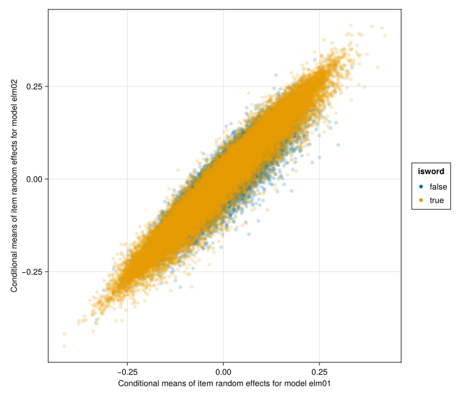

Figure 9: Conditional means of scalar random effects for item in model elm01, fit to the pruned data, versus those for model elm02, fit to the pruned data with inaccurate subjects removed.

```julia
CairoMakie.activate!(; type="png")
disallowmissing!(
  leftjoin!(
    byitem,
    leftjoin!(
      rename!(DataFrame(raneftables(elm01)[:item]), [:item, :elm01]),
      rename!(DataFrame(raneftables(elm02)[:item]), [:item, :elm02]);
      on=:item,
    ),
    on=:item,
  ),
)
disallowmissing!(
  leftjoin!(
    bysubj,
    leftjoin!(
      rename!(DataFrame(raneftables(elm01)[:subj]), [:subj, :elm01]),
      rename!(DataFrame(raneftables(elm02)[:subj]), [:subj, :elm02]);
      on=:subj,
    ),
    on=:subj,
  ); error=false,
)
draw(
  data(byitem) * mapping(
    :elm01 => "Conditional means of item random effects for model elm01",
    :elm02 => "Conditional means of item random effects for model elm02";
    color=:isword,
  ) * visual(Scatter; alpha=0.2);
  axis=(; width=600, height=600),
)
```

**Note**

Adjust the alpha on Figure 9.

Figure 9 is exactly of the form that would be expected in a sample from a correlated multivariate Gaussian distribution. The correlation of the two sets of conditional means is about 96%.

```julia
cor(Matrix(select(byitem, :elm01, :elm02)))
```

```
2×2 Matrix{Float64}:
 1.0       0.958655
 0.958655  1.0
```

These models take only a few seconds to fit on a modern laptop computer, which is quite remarkable given the size of the data set and the number of random effects.

The amount of time to fit more complex models will be much greater so we may want to move those fits to more powerful server computers. We can split the tasks of fitting and analyzing a model between computers by saving the optimization summary after the model fit and later creating the `MixedModel` object followed by restoring the `optsum` object.

```julia
saveoptsum("./fits/elm01.json", elm01);
```

```julia
elm01a = restoreoptsum!(
  let
    form = @formula(
      1000 / rt ~ 1 + isword * wrdlen + (1 | item) + (1 | subj)
    )
    MixedModel(form, pruned; contrasts)
  end,
  "./fits/elm01.json",
)
```

|  | Est. | SE | z | p | σ_item | σ_subj |
| --- | --- | --- | --- | --- | --- | --- |
| (Intercept) | 1.3758 | 0.0090 | 153.69 | <1e-99 | 0.1185 | 0.2550 |
| isword: true | 0.0625 | 0.0005 | 131.35 | <1e-99 |  |  |
| wrdlen(centered: 8) | -0.0436 | 0.0002 | -225.38 | <1e-99 |  |  |
| isword: true & wrdlen(centered: 8) | -0.0056 | 0.0002 | -28.83 | <1e-99 |  |  |
| Residual | 0.3781 |  |  |  |  |  |

Other covariates associated with the item are available as

```julia
elpldtitem = DataFrame(dataset("ELP_ldt_item"))
describe(elpldtitem)
```

9×7 DataFrame

| Row | variable Symbol | mean Union… | min Any | median Union… | max Any | nmissing Int64 | eltype Type |
| --- | --- | --- | --- | --- | --- | --- | --- |
| 1 | item |  | Aarod |  | zuss | 0 | String |
| 2 | Ortho_N | 1.53309 | 0 | 1.0 | 25 | 0 | Int8 |
| 3 | BG_Sum | 13938.4 | 11 | 13026.0 | 59803 | 177 | Union{Missing, Int32} |
| 4 | BG_Mean | 1921.25 | 5.5 | 1907.0 | 6910.0 | 177 | Union{Missing, Float32} |
| 5 | BG_Freq_By_Pos | 2043.08 | 0 | 1928.0 | 6985 | 4 | Union{Missing, Int16} |
| 6 | itemno | 40481.5 | 1 | 40481.5 | 80962 | 0 | Int32 |
| 7 | isword | 0.5 | false | 0.5 | true | 0 | Bool |
| 8 | wrdlen | 7.9988 | 1 | 8.0 | 21 | 0 | Int8 |
| 9 | pairno | 20241.0 | 1 | 20241.0 | 40481 | 0 | Int32 |

and those associated with the subject are

```julia
elpldtsubj = DataFrame(dataset("ELP_ldt_subj"))
describe(elpldtsubj)
```

20×7 DataFrame

| Row | variable Symbol | mean Union… | min Any | median Any | max Any | nmissing Int64 | eltype Type |
| --- | --- | --- | --- | --- | --- | --- | --- |
| 1 | subj |  | S001 |  | S816 | 0 | String |
| 2 | univ |  | Kansas |  | Wayne State | 0 | String |
| 3 | sex |  | f |  | m | 8 | Union{Missing, String} |
| 4 | DOB |  | 1938-06-07 |  | 1984-11-14 | 0 | Date |
| 5 | MEQ | 44.4932 | 19.0 | 44.0 | 75.0 | 8 | Union{Missing, Float32} |
| 6 | vision | 5.51169 | 0 | 6.0 | 7 | 1 | Union{Missing, Int8} |
| 7 | hearing | 5.86101 | 0 | 6.0 | 7 | 1 | Union{Missing, Int8} |
| 8 | educatn | 8.89681 | 1 | 12.0 | 28 | 0 | Int8 |
| 9 | ncorrct | 29.8505 | 5 | 30.0 | 40 | 18 | Union{Missing, Int8} |
| 10 | rawscor | 31.9925 | 13 | 32.0 | 40 | 18 | Union{Missing, Int8} |
| 11 | vocabAge | 17.8123 | 10.3 | 17.8 | 21.0 | 19 | Union{Missing, Float32} |
| 12 | shipTime | 3.0861 | 0 | 3.0 | 9 | 1 | Union{Missing, Int8} |
| 13 | readTime | 2.50215 | 0.0 | 2.0 | 15.0 | 1 | Union{Missing, Float32} |
| 14 | preshlth | 5.48708 | 0 | 6.0 | 7 | 1 | Union{Missing, Int8} |
| 15 | pasthlth | 4.92989 | 0 | 5.0 | 7 | 1 | Union{Missing, Int8} |
| 16 | S1start |  | 2001-03-16T13:49:27 | 2001-10-16T11:38:28.500 | 2003-07-29T18:48:44 | 0 | DateTime |
| 17 | S2start |  | 2001-03-19T10:00:35 | 2001-10-19T14:24:19.500 | 2003-07-30T13:07:45 | 0 | DateTime |
| 18 | MEQstrt |  | 2001-03-22T18:32:00 | 2001-10-23T11:26:13 | 2003-07-30T14:30:49 | 7 | Union{Missing, DateTime} |
| 19 | filename |  | 101DATA.LDT |  | Data998.LDT | 0 | String |
| 20 | frstLang |  | English |  | other | 8 | Union{Missing, String} |

For the simple model `elm01` the estimated standard deviation of the random effects for subject is greater than that of the random effects for item, a common occurrence. A caterpillar plot, Figure 10,

```julia
qqcaterpillar!(
  Figure(resolution=(800, 650)),
  ranefinfo(elm01, :subj),
)
```

```
┌ Warning: Found `resolution` in the theme when creating a `Scene`. The `resolution` keyword for `Scene`s and `Figure`s has been deprecated. Use `Figure(; size = ...` or `Scene(; size = ...)` instead, which better reflects that this is a unitless size and not a pixel resolution. The key could also c…
└ @ Makie ~/.julia/packages/Makie/WgbrE/src/scenes.jl:227
```

[figure not shown]

Figure 10: Conditional means and 95% prediction intervals for subject random effects in elm01.

shows definite distinctions between subjects because the widths of the prediction intervals are small compared to the range of the conditional modes. Also, there is at least one outlier with a conditional mode over 1.0.

Figure 11 is the corresponding caterpillar plot for model `elm02` fit to the data with inaccurate responders eliminated.

```julia
qqcaterpillar!(
  Figure(resolution=(800, 650)),
  ranefinfo(elm02, :subj),
)
```

```
┌ Warning: Found `resolution` in the theme when creating a `Scene`. The `resolution` keyword for `Scene`s and `Figure`s has been deprecated. Use `Figure(; size = ...` or `Scene(; size = ...)` instead, which better reflects that this is a unitless size and not a pixel resolution. The key could also c…
└ @ Makie ~/.julia/packages/Makie/WgbrE/src/scenes.jl:227
```

[figure not shown]

Figure 11: Conditional means and 95% prediction intervals for subject random effects in elm02.

## 2.4 Random effects from the simple model related to covariates

The random effects “estimates” (technically they are “conditional means”) from the simple model `elm01` provide a measure of how much the item or subject differs from the population. (We use `elm01` because the main difference between `elm01` and `elm02` are that some subjects were dropped before fitting `elm02`.)

For the item its length and word/non-word status have already been incorporated in the model. At this point the subjects are just being treated as a homogeneous population.

The random effects conditional means have been extracted and incorporated in the `byitem` and `bysubj` tables. Now add selected demographic and item-specific measures.

```julia
itemextended = leftjoin(
  byitem,
  select(elpldtitem, 1:5);
  on = :item,
)
subjextended = leftjoin(
  bysubj,
  select(elpldtsubj, 1:3, :vocabAge);
  on=:subj,
)
```

814×11 DataFrame

789 rows omitted

| Row | subj String | ns Int64 | smiss Int64 | sacc Int64 | smedianrt Float64 | spropacc Float64 | elm01 Float64 | elm02 Float64? | univ String? | sex String? | vocabAge Float32? |
| --- | --- | --- | --- | --- | --- | --- | --- | --- | --- | --- | --- |
| 1 | S001 | 3374 | 0 | 3158 | 554.0 | 0.935981 | 0.411459 | 0.426624 | Morehead | m | 19.8 |
| 2 | S002 | 3372 | 1 | 3031 | 960.0 | 0.898873 | -0.30907 | -0.293732 | Morehead | f | 17.8 |
| 3 | S003 | 3372 | 3 | 3006 | 813.0 | 0.891459 | -0.153078 | -0.139436 | Morehead | f | 18.2 |
| 4 | S004 | 3374 | 1 | 3062 | 619.0 | 0.907528 | 0.213047 | 0.22754 | Morehead | f | 18.6 |
| 5 | S005 | 3374 | 0 | 2574 | 677.0 | 0.762893 | 0.0850349 | missing | Morehead | f | 16.2 |
| 6 | S006 | 3374 | 0 | 2927 | 855.0 | 0.867516 | -0.207356 | -0.192651 | Morehead | f | 17.8 |
| 7 | S007 | 3374 | 4 | 2877 | 918.5 | 0.852697 | -0.182201 | -0.166357 | Morehead | f | 17.4 |
| 8 | S008 | 3372 | 1 | 2731 | 1310.0 | 0.809905 | -0.541434 | -0.526828 | Morehead | m | 16.2 |
| 9 | S009 | 3374 | 13 | 2669 | 657.0 | 0.791049 | 0.154926 | missing | Morehead | f | 16.6 |
| 10 | S010 | 3374 | 0 | 2722 | 757.0 | 0.806758 | -0.0541104 | -0.0403266 | Morehead | f | 17.0 |
| 11 | S011 | 3374 | 0 | 2894 | 632.0 | 0.857736 | 0.217734 | 0.231618 | Morehead | f | 17.4 |
| 12 | S012 | 3374 | 4 | 2979 | 692.0 | 0.882928 | 0.062351 | 0.0770981 | Morehead | m | 18.2 |
| 13 | S013 | 3374 | 2 | 2980 | 1114.0 | 0.883225 | -0.409761 | -0.3956 | Morehead | f | 18.2 |
| ⋮ | ⋮ | ⋮ | ⋮ | ⋮ | ⋮ | ⋮ | ⋮ | ⋮ | ⋮ | ⋮ | ⋮ |
| 803 | S805 | 3374 | 5 | 2881 | 534.0 | 0.853883 | 0.480461 | 0.495683 | Wash. Univ | m | 19.0 |
| 804 | S806 | 3374 | 1 | 3097 | 841.5 | 0.917902 | -0.1888 | -0.173376 | Wash. Univ | m | 19.8 |
| 805 | S807 | 3374 | 3 | 2994 | 704.0 | 0.887374 | 0.01919 | 0.0338241 | Wash. Univ | m | 17.4 |
| 806 | S808 | 3374 | 2 | 2751 | 630.5 | 0.815353 | 0.199416 | 0.214299 | Wash. Univ | f | 18.6 |
| 807 | S809 | 3372 | 4 | 2603 | 627.0 | 0.771945 | 0.2277 | missing | Wash. Univ | m | 15.1 |
| 808 | S810 | 3374 | 1 | 3242 | 603.5 | 0.960877 | 0.252522 | 0.266822 | Wash. Univ | m | 19.8 |
| 809 | S811 | 3374 | 2 | 2861 | 827.0 | 0.847955 | -0.158097 | -0.143568 | Wash. Univ | f | 16.2 |
| 810 | S812 | 3372 | 6 | 3012 | 471.0 | 0.893238 | 0.748427 | 0.76354 | Wash. Univ | f | 19.8 |
| 811 | S813 | 3372 | 4 | 2932 | 823.0 | 0.869514 | -0.167166 | -0.153846 | Wash. Univ | m | 17.4 |
| 812 | S814 | 3374 | 1 | 3070 | 773.0 | 0.909899 | -0.0753662 | -0.0606956 | Wash. Univ | f | 18.6 |
| 813 | S815 | 3374 | 1 | 3024 | 602.0 | 0.896266 | 0.249134 | 0.2643 | Wash. Univ | f | 18.6 |
| 814 | S816 | 3374 | 0 | 2950 | 733.0 | 0.874333 | -0.0364596 | -0.0222916 | Wash. Univ | f | 17.8 |

As shown in Figure 12, there does not seem to be a strong relationship between vocabulary age and speed of response by subject.

```julia
draw(
  data(dropmissing(select(subjextended, :elm01, :vocabAge, :sex))) *
  mapping(
    :vocabAge => "Vocabulary age (yr) of subject",
    :elm01 => "Random effect in model elm01";
    color=:sex,
  ) * visual(Scatter; alpha=0.6)
)
```

[figure not shown]

Figure 12: Random effect for subject in model elm01 versus vocabulary age

```julia
draw(
  data(dropmissing(select(subjextended, :elm01, :univ))) *
  mapping(
    :elm01 => "Random effect in model elm01";
    color=:univ => "University",
  ) * AlgebraOfGraphics.density()
)
```

[figure not shown]

Figure 13: Estimated density of random effects for subject in model elm01 by university

```julia
draw(
  data(dropmissing(select(subjextended, :elm02, :univ))) *
  mapping(
    :elm02 => "Random effect in model elm02 (accurate responders only)";
    color=:univ => "University",
  ) * AlgebraOfGraphics.density()
)
```

[figure not shown]

Figure 14: Estimated density of random effects for subject in model elm02, fit to accurate responders only, by university

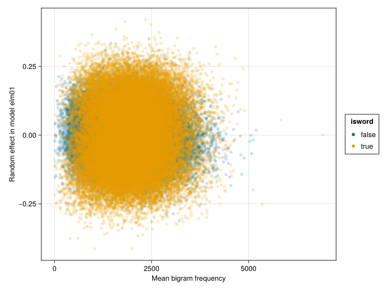

Figure 15: Random effect in model elm01 versus mean bigram frequency, by word/nonword status

```julia
CairoMakie.activate!(; type="png")
draw(
  data(dropmissing(select(itemextended, :elm01, :BG_Mean, :isword))) *
  mapping(
    :BG_Mean => "Mean bigram frequency",
    :elm01 => "Random effect in model elm01";
    color=:isword,
  ) * visual(Scatter; alpha=0.2)
)
```

Back to top

## References

Balota, D. A., Yap, M. J., Hutchison, K. A., Cortese, M. J., Kessler, B., Loftis, B., Neely, J. H., Nelson, D. L., Simpson, G. B., & Treiman, R. (2007). The english lexicon project. *Behavior Research Methods*, *39*(3), 445–459. https://doi.org/10.3758/bf03193014

Box, G. E. P., & Cox, D. R. (1964). An analysis of transformations. *Journal of the Royal Statistical Society: Series B (Methodological)*, *26*(2), 211–243. https://doi.org/10.1111/j.2517-6161.1964.tb00553.x